# ĐỒ ÁN CUỐI KỲ

NHÓM 12

2023-12-15

```
                                          REPORT
                                          NHÓM 12
```

# LỜI CẢM ƠN

Để có thể hoàn thành đồ án một cách hoàn chỉnh, bên cạnh sự nỗ lực cố gắng của các thành viên trong nhóm còn có sự hướng dẫn nhiệt tình của thầy, sự động viên ủng hộ của gia đình và bạn bè trong suốt thời gian học tập nghiên cứu và thực hiện đồ án. Trước hết, nhóm em xin gửi lời cảm ơn chân thành nhất đến thầy Trần Trọng Bình, vô cùng bận bịu nhưng vẫn luôn giành thời gian để giải đáp những thắc mắc cũng như đã hết lòng giúp đỡ, chỉ bảo, tạo mọi điều kiện tốt nhất cho nhóm em hoàn thành đồ án này. Bên cạnh đó, cũng xin chân thành bày tỏ lòng biết ơn đến toàn thể quý thầy cô trong Khoa Công Nghệ Thông Tin, Trường Đại học Sư phạm Kỹ thuật TP.HCM đã tận tình truyền đạt những kiến thức quý báu cũng như tạo mọi điều kiện thuận lợi nhất cho nhóm em trong suốt quá trình học tập và cho đến khi thực hiện đồ án. Với kiến thức và trình độ lý luận còn hạn chế, đồ án này không thể tránh khỏi những điều thiếu sót. Vì vậy nhóm em rất mong nhận được những ý kiến đóng góp, nhận xét và sự chỉ bảo của cô để nhóm em có thể học hỏi hêm những kiến thức và kinh nghiệm cho bản thân, phục vụ cho quá trình học tập sau này. Xin chân thành cảm ơn!

# 1. TÓM TẮT (ABSTRACT)

Theo tình hình thế giới hiện nay, con người đang phải đối diện với các nguy hiểm từ các căn bệnh phức tạp kèm theo đó là tỷ lệ tử vong cao và đột quỵ là một trong số chúng. Theo thống kê, số lượng bệnh nhân đột quỵ trẻ ngày càng gia tăng. Hiện nay bệnh nhân đột quỵ dưới 40 tuổi đã chiếm 5% trong số bệnh nhân đột quỵ. Theo Tổ chức Y tế thế giới, mỗi năm có khoảng 6,5 triệu người tử vong do đột quỵ. Đây cũng là nguyên nhân gây tử vong cao thứ hai trên thế giới, chiếm khoảng 11% tổng số ca tử vong. Trung bình có 1 ca tử vong do đột quỵ sau mỗi 6 giây và cứ 6 người thì có 1 người bị đột quỵ. Nhận thấy tính nghiêm trọng của căn bệnh này với nhu cầu giúp ích trong việc phòng ngừa ngăn chặn bệnh đột quỵ, chúng em quyết định chọn đề tài “Phân tích nguyên nhân và dự đoán đột quỵ”.

# 2. GIỚI THIỆU (INTRODUCE)

Để hiểu rõ được nguyên nhân dẫn đến đột quỵ, từ đó đưa ra những nhận xét và đánh giá cho dự đoán này, nhóm chúng em đã đặt ra những vấn đề nghiên cứu sau:

Các yếu tố ảnh hưởng đến tỷ lệ đột quỵ và tỷ lệ ảnh hưởng của chúng:

- Biến giải thích (X): 11 biến trong bộ dữ liệu (trừ biến id).
- Biến kết quả (Y): stroke.
- Biểu đồ sử dụng (dự tính): Biểu đồ khảm (mosaic plots), bản đồ nhiệt tương quan (correlation heatmap), biểu đồ phân tán (scatter plot).
- Phương pháp sử dụng: sử dụng biểu đồ trực quan, thu thập dữ liệu, xử lí dữ liệu, thống kê.
- Ý nghĩa: xác định đượng mối quan hệ giữa các biến X và Y từ đó đưa ra kết luận.

  Thống kê độ tuổi thường mắc đột quỵ:
- Biến giải thích (X): stroke, age.
- Biến kết quả (Y): một biến tạm lưu độ tuổi có nguy cơ đột quỵ cao nhất.
- Biểu đồ sử dụng (dự tính): Biểu đồ tần suất (histogram), biểu đồ hộp (boxplot), bản đồ nhiệt tương quan (correlation heatmap), biểu đồ phân tán (scatter plot).
- Phương pháp sử dụng: Thống kê suy luận (Inferential statistics) - là bao gồm các phương pháp ước lượng các đặc trưng của tổng thể, phân tích mối liên hệ giữa các hiện tượng nghiên cứu, dự đoán hoặc ra quyết định trên cơ sở thu thập thông tin từ kết quả quan sát mẫu.
- Ý nghĩa: Từ thống kê này ta có thể xác định độ tuổi có tương quan lớn nhẩt với đột quỵ.

  Xây dựng chương trình dự đoán nguy cơ đột quỵ:
- Biến giải thích (X): 11 biến trong bộ dữ liệu (trừ biến id).
- Biến kết quả (Y): 1 biến chứa tỷ lệ đột quỵ.
- Biểu đồ sử dụng: Biểu đồ tần suất(histogram), biểu đồ hộp (boxplot), bản đồ nhiệt tương quan(correlation heatmap), biểu đồ phân tán (scatter plot), Line Graph(biểu đồ đường).
- Phương pháp sử dụng: Logistic Regression (hồi quy logistic), Random Forest, Decision Tree …
- Ý nghĩa: sau khi thực hiện sẽ xuất ra kết quả là 1 tỷ lệ đột quỵ dựa trên các dữ liệu đầu vào.

# 3. DỮ LIỆU (DATA)

Dữ liệu được lấy trên Kaggle có URL: https://www.kaggle.com/code/joshuaswords/predicting-a-stroke-shap-lime-explainer-eli5/data.

- id: định danh duy nhất

- gender: “Nam”, “Nữ” hoặc “Khác”

- age: tuổi của bệnh nhân

- hypertension: 0 nếu bệnh nhân không bị tăng huyết áp, 1 nếu bệnh nhân bị tăng huyết áp

- heart_disease: 0 nếu bệnh nhân không mắc bất kỳ bệnh tim nào, 1 nếu bệnh nhân có bệnh tim

- ever_married : đã từng kết hôn “Không” hoặc “Có”

- work_type: “children”, “Govt_jov”, “Never_worked”, “Tư nhân” hoặc “Tự kinh doanh”

- Residence_type: “Nông thôn” hoặc “Thành thị”

- avg_glucose_level: mức đường trung bình trong máu

- BMI: chỉ số khối cơ thể - smoking_status: “trước đây đã hút thuốc”, “chưa bao giờ hút thuốc”, “hút thuốc”hoặc “Không xác định” (“Không xác định” trong smoking_status có nghĩa là thông tin không có sẵn cho bệnh nhân này)

- stroke: 1 nếu bệnh nhân bị đột quỵ hoặc 0 nếu không

# 4. TRỰC QUAN HÓA DỮ LIỆU (DATA VISULIZATION)

- Bộ dữ liệu này được lấy từ trang kaggle chứa dữ liệu các bệnh nhân có bị đột quỵ hoặc là không bị đột quỵ và các thông tin liên quan như giới tính, tuổi tác, các bệnh nền và tình trạng hôn nhân, có hút thuốc không,… Mỗi hàng trong dữ liệu cung cấp thông tin liên quan về bệnh nhân.
- Bộ dữ liệu gồm 5110 hàng và 12 cột, trong đó gồm 11 cột chứa biến có ích cho việc phân tích và cột id là không cần thiết.

## Đọc dữ liệu và lưu trữ trong data, hàm str() được sử dụng để xem cấu trúc của đối tượng đó.

```r
data <- read.csv("./healthcare-dataset-stroke-data.csv", header = T)
str(data)
```

```
## 'data.frame':    5110 obs. of  12 variables:
##  $ id               : int  9046 51676 31112 60182 1665 56669 53882 10434 27419 60491 ...
##  $ gender           : chr  "Male" "Female" "Male" "Female" ...
##  $ age              : num  67 61 80 49 79 81 74 69 59 78 ...
##  $ hypertension     : int  0 0 0 0 1 0 1 0 0 0 ...
##  $ heart_disease    : int  1 0 1 0 0 0 1 0 0 0 ...
##  $ ever_married     : chr  "Yes" "Yes" "Yes" "Yes" ...
##  $ work_type        : chr  "Private" "Self-employed" "Private" "Private" ...
##  $ Residence_type   : chr  "Urban" "Rural" "Rural" "Urban" ...
##  $ avg_glucose_level: num  229 202 106 171 174 ...
##  $ bmi              : chr  "36.6" "N/A" "32.5" "34.4" ...
##  $ smoking_status   : chr  "formerly smoked" "never smoked" "never smoked" "smokes" ...
##  $ stroke           : int  1 1 1 1 1 1 1 1 1 1 ...
```

## In tập dữ liệu

```r
head (data)
```

```
##      id gender age hypertension heart_disease ever_married     work_type
## 1  9046   Male  67            0             1          Yes       Private
## 2 51676 Female  61            0             0          Yes Self-employed
## 3 31112   Male  80            0             1          Yes       Private
## 4 60182 Female  49            0             0          Yes       Private
## 5  1665 Female  79            1             0          Yes Self-employed
## 6 56669   Male  81            0             0          Yes       Private
##   Residence_type avg_glucose_level  bmi  smoking_status stroke
## 1          Urban            228.69 36.6 formerly smoked      1
## 2          Rural            202.21  N/A    never smoked      1
## 3          Rural            105.92 32.5    never smoked      1
## 4          Urban            171.23 34.4          smokes      1
## 5          Rural            174.12   24    never smoked      1
## 6          Urban            186.21   29 formerly smoked      1
```

## Hàng và cột của tập dữ liệu

```r
nrow(data)
```

```
## [1] 5110
```

```r
ncol(data)
```

```
## [1] 12
```

## Làm sạch dữ liệu

```r
#Bỏ đi cột ID vì không cần thiết
stroke = subset(data, select = -c(id))

#Chuyển dữ liệu cột bmi sang dạng số để có thể tính toán
suppressWarnings(stroke$bmi <- as.numeric(as.character(stroke$bmi)))

# Kiểm tra lại số null trong bộ dữ liệu
colSums(is.na(stroke))
```

```
##            gender               age      hypertension     heart_disease
##                 0                 0                 0                 0
##      ever_married         work_type    Residence_type avg_glucose_level
##                 0                 0                 0                 0
##               bmi    smoking_status            stroke
##               201                 0                 0
```

```r
bmi.median = median(stroke$bmi, na.rm = TRUE)
stroke$bmi <- stroke$bmi %>% replace_na(bmi.median)
```

### Kiểm tra cột gender

```r
as.data.frame(table(stroke$gender))
```

```
##     Var1 Freq
## 1 Female 2994
## 2   Male 2115
## 3  Other    1
```

### Do có một giá trị ‘other’ nên tiến hành xoá nó khỏi cột gender

```r
stroke = stroke[!stroke$gender == 'Other',]
```

### Kiểm tra cột work

```r
as.data.frame(table(stroke$work_type))
```

```
##            Var1 Freq
## 1      children  687
## 2      Govt_job  657
## 3  Never_worked   22
## 4       Private 2924
## 5 Self-employed  819
```

### Kiểm tra cột Residence_type

```r
as.data.frame(table(stroke$Residence_type))
```

```
##    Var1 Freq
## 1 Rural 2513
## 2 Urban 2596
```

### Kiểm tra cột ever_married

```r
as.data.frame(table(stroke$ever_married))
```

```
##   Var1 Freq
## 1   No 1756
## 2  Yes 3353
```

### Kiểm tra cột smoking_status

```r
as.data.frame(table(stroke$smoking_status))
```

```
##              Var1 Freq
## 1 formerly smoked  884
## 2    never smoked 1892
## 3          smokes  789
## 4         Unknown 1544
```

### Vì cột smoking có các giá trị unknown nhưng để tiện phân tích ảnh hưởng của hút thuốc đối với tỷ lệ đột quỵ nên ta tiến hành thay thế các giá trị unknown thành giá trị có số lượng nhiều nhất là never smoked

```r
stroke <- stroke %>% mutate(smoking_status = replace(smoking_status, smoking_status == "Unknown", "never smoked"))
#kiểm tra lại bộ dữ liệu
head(stroke)
```

```
##   gender age hypertension heart_disease ever_married     work_type
## 1   Male  67            0             1          Yes       Private
## 2 Female  61            0             0          Yes Self-employed
## 3   Male  80            0             1          Yes       Private
## 4 Female  49            0             0          Yes       Private
## 5 Female  79            1             0          Yes Self-employed
## 6   Male  81            0             0          Yes       Private
##   Residence_type avg_glucose_level  bmi  smoking_status stroke
## 1          Urban            228.69 36.6 formerly smoked      1
## 2          Rural            202.21 28.1    never smoked      1
## 3          Rural            105.92 32.5    never smoked      1
## 4          Urban            171.23 34.4          smokes      1
## 5          Rural            174.12 24.0    never smoked      1
## 6          Urban            186.21 29.0 formerly smoked      1
```

### Check lại giá trị na trong dữ liệu

```r
colSums(is.na(stroke))
```

```
##            gender               age      hypertension     heart_disease
##                 0                 0                 0                 0
##      ever_married         work_type    Residence_type avg_glucose_level
##                 0                 0                 0                 0
##               bmi    smoking_status            stroke
##                 0                 0                 0
```

# Tạo một bản sao của tập dữ liệu

```r
stroke1 <- stroke
#stroke1
```

### Chuyển các biến kiểu phân loại vào factor

```r
stroke$stroke <- as.factor(stroke$stroke)
stroke$hypertension <- as.factor(stroke$hypertension)
stroke$heart_disease <- as.factor(stroke$heart_disease)
stroke$ever_married <- as.factor(stroke$ever_married)
stroke$Residence_type <- as.factor(stroke$Residence_type)
```

# Đặt các biến đa cấp thành biến giả

```r
stroke_dummy <- dummy_cols(stroke,select_columns = c("gender","work_type","smoking_status"),remove_first_dummy = TRUE, remove_selected_columns = TRUE)
stroke_dummy %>% head()
```

```
##   age hypertension heart_disease ever_married Residence_type avg_glucose_level
## 1  67            0             1          Yes          Urban            228.69
## 2  61            0             0          Yes          Rural            202.21
## 3  80            0             1          Yes          Rural            105.92
## 4  49            0             0          Yes          Urban            171.23
## 5  79            1             0          Yes          Rural            174.12
## 6  81            0             0          Yes          Urban            186.21
##    bmi stroke gender_Male work_type_Govt_job work_type_Never_worked
## 1 36.6      1           1                  0                      0
## 2 28.1      1           0                  0                      0
## 3 32.5      1           1                  0                      0
## 4 34.4      1           0                  0                      0
## 5 24.0      1           0                  0                      0
## 6 29.0      1           1                  0                      0
##   work_type_Private work_type_Self-employed smoking_status_never smoked
## 1                 1                       0                           0
## 2                 0                       1                           1
## 3                 1                       0                           1
## 4                 1                       0                           0
## 5                 0                       1                           1
## 6                 1                       0                           0
##   smoking_status_smokes
## 1                     0
## 2                     0
## 3                     0
## 4                     1
## 5                     0
## 6                     0
```

## *** Khai phá dữ liệu (EDA)

### Xem xét phân phối của từng biến riêng lẻ

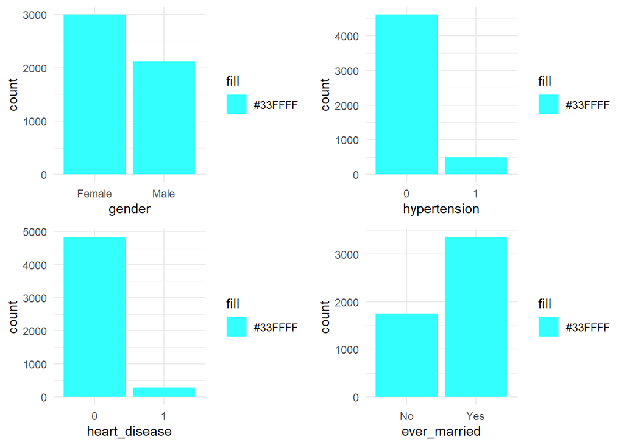

```r
library(ggplot2)
library(gridExtra)

# Thiết lập màu chung cho tất cả biểu đồ
my_color <- "#33FFFF"

# Tạo biểu đồ cho từng biến phân loại
p1 <- ggplot(data = stroke) + geom_bar(mapping = aes(x = gender, fill = "#33FFFF")) +
      scale_fill_manual(values = "#33FFFF") + theme_minimal()

p2 <- ggplot(data = stroke) + geom_bar(mapping = aes(x = hypertension, fill = "#33FFFF")) +
      scale_fill_manual(values = "#33FFFF") + theme_minimal()

p3 <- ggplot(data = stroke) + geom_bar(mapping = aes(x = heart_disease, fill = "#33FFFF")) +
      scale_fill_manual(values = "#33FFFF") + theme_minimal()

p4 <- ggplot(data = stroke) + geom_bar(mapping = aes(x = ever_married, fill = "#33FFFF")) +
      scale_fill_manual(values = my_color) + theme_minimal()

# Sắp xếp biểu đồ vào một bảng có 2 cột
grid.arrange(p1, p2, p3, p4, ncol = 2)
```

===> Dựa vào biểu dồ trên, có thể thấy phần lớn trường hợp bệnh nhân không mắc bệnh tim và huyết áp, người đã kết hôn và nữ giới chiếm đa số trong tập dữ liệu.

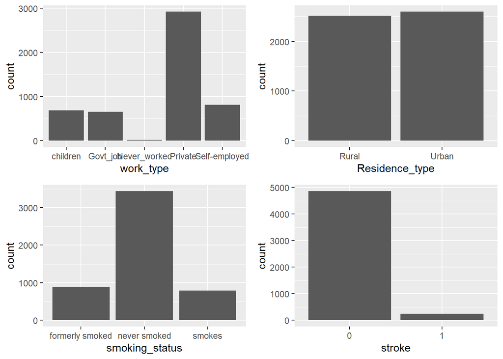

```r
p5 <-ggplot(data = stroke) +geom_bar(mapping = aes(x = work_type))
p6 <-ggplot(data = stroke) +geom_bar(mapping = aes(x = Residence_type))
p7 <-ggplot(data = stroke) +geom_bar(mapping = aes(x = smoking_status))
p8 <-ggplot(data = stroke) +geom_bar(mapping = aes(x = stroke))
grid.arrange(p5,p6,p7,p8, ncol= 2)
```

===> Hầu hết các trường hợp trong tập dữ liệu bệnh nhân không bị đột quỵ, công nhân tư nhân và không hút thuốc chiếm đa số, có sự chênh lệch thấp giữa nông thôn và thành thị.

### Xem xét phân phối của các biến liên tục

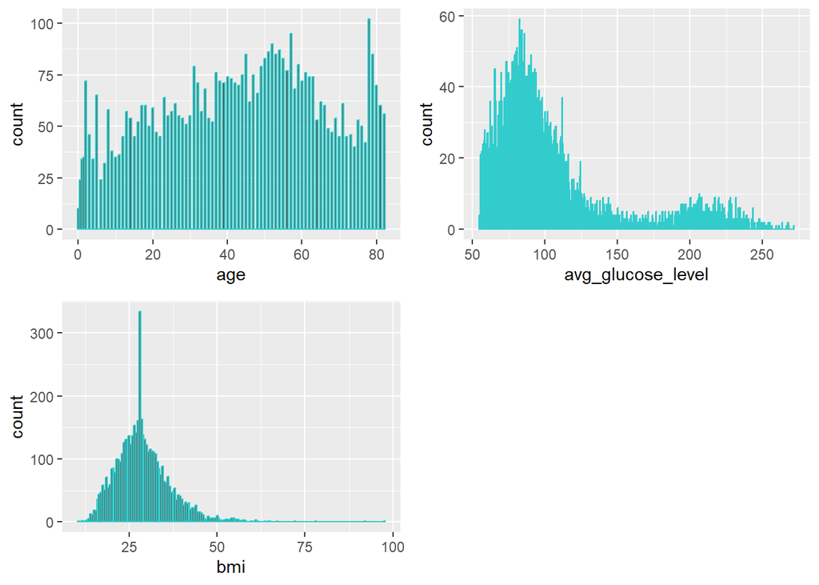

```r
c1 <- ggplot(data = stroke) + geom_histogram(mapping = aes(x = age), binwidth = 0.5, col = '#33CCCC')
c2 <- ggplot(data = stroke) + geom_histogram(mapping = aes(x = avg_glucose_level), binwidth = 0.5, col = '#33CCCC')
c3 <- ggplot(data = stroke) + geom_histogram(mapping = aes(x = bmi), binwidth = 0.5, col = '#33CCCC')
grid.arrange(c1,c2,c3, ncol= 2)
```

# Tiếp theo ta sẽ kiểm tra mối quan hệ giữa các biến đầu vào và biến kết quả của chúng thông qua boxplot và từ đó đưa ra nhận xét “CÁC YẾU TỐ ẢNH HƯỞNG ĐẾN TỶ LỆ ĐỘT QUỴ VÀ ẢNH HƯỞNG CỦA CHÚNG”.

### Đột quỵ với tuổi tác

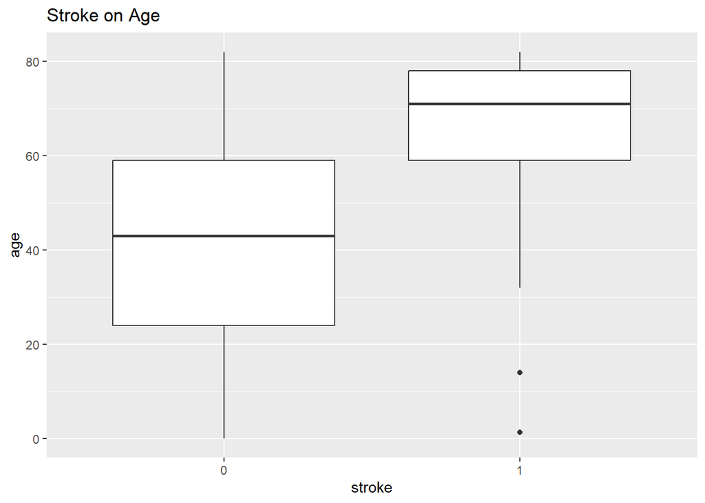

```r
ggplot(data = stroke, mapping = aes(x = stroke, y = age)) +geom_boxplot()+labs(title='Stroke on Age')
```

### Đột quỵ với lượng đường

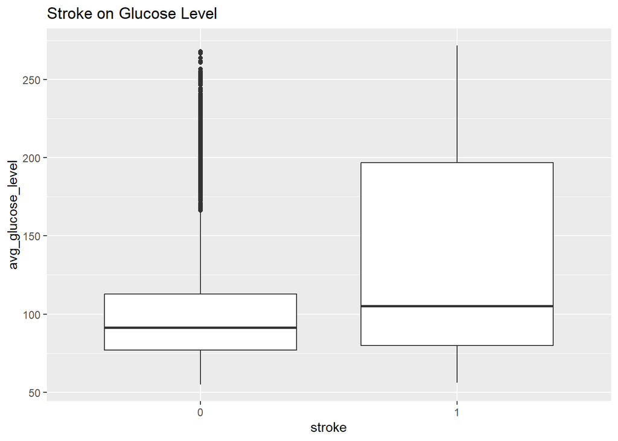

```r
ggplot(data = stroke, mapping = aes(x = stroke, y = avg_glucose_level)) +geom_boxplot()+labs(title='Stroke on Glucose Level')
```

### Đột quỵ với chỉ số cơ thể

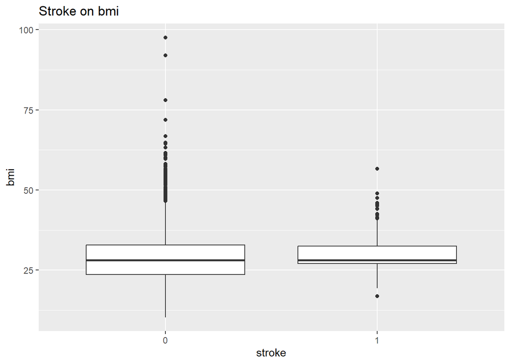

```r
ggplot(data = stroke, mapping = aes(x = stroke, y = bmi)) +geom_boxplot()+labs(title='Stroke on bmi')
```

## Để xem mối quan hệ của các biến phân loại đối với đột quỵ ta dùng biểu đồ khảm để có cái nhìn trực quan nhất

### Đột quỵ với loại hình việc làm

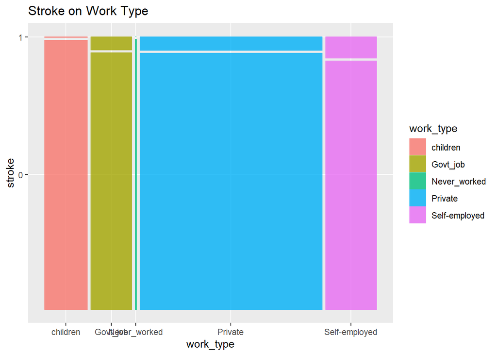

```r
ggplot(data = stroke) +geom_mosaic(aes(x = product(stroke,work_type), fill=work_type)) + labs(title='Stroke on Work Type')
```

### Đột quỵ với việc hút thuốc

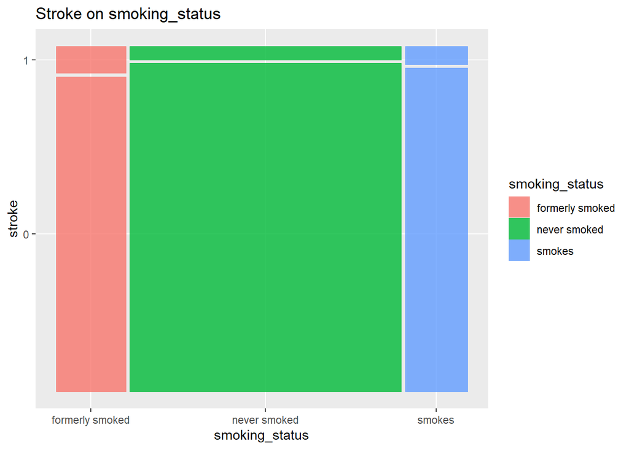

```r
ggplot(data = stroke) +geom_mosaic(aes(x = product(stroke,smoking_status), fill=smoking_status)) + labs(title='Stroke on smoking_status')
```

### Đột quỵ với huyết áp

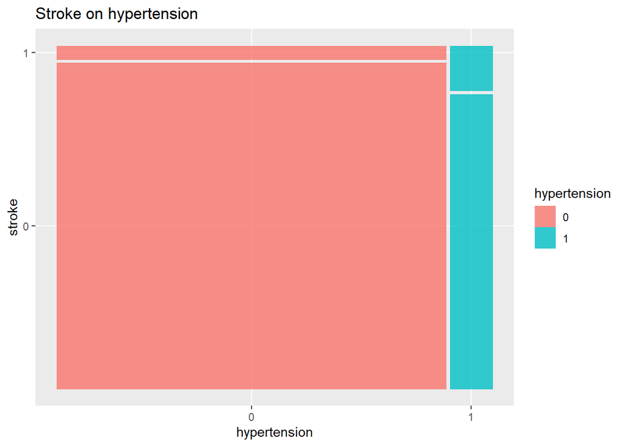

```r
ggplot(data = stroke) +geom_mosaic(aes(x = product(stroke,hypertension), fill=hypertension)) + labs(title='Stroke on hypertension')
```

### Đột quỵ với việc kết hôn

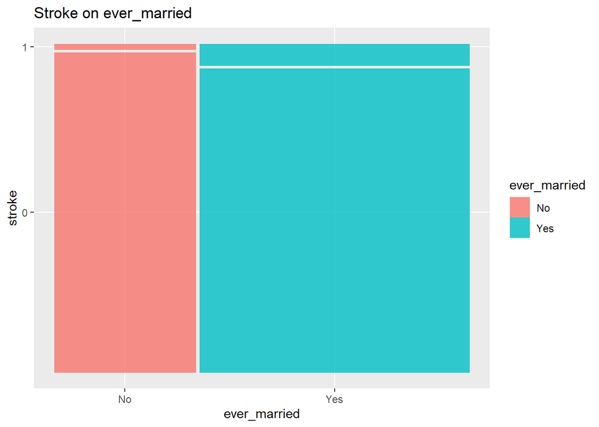

```r
ggplot(data = stroke) +geom_mosaic(aes(x = product(stroke,ever_married), fill=ever_married)) + labs(title='Stroke on ever_married')
```

### Đột quỵ với bệnh tim

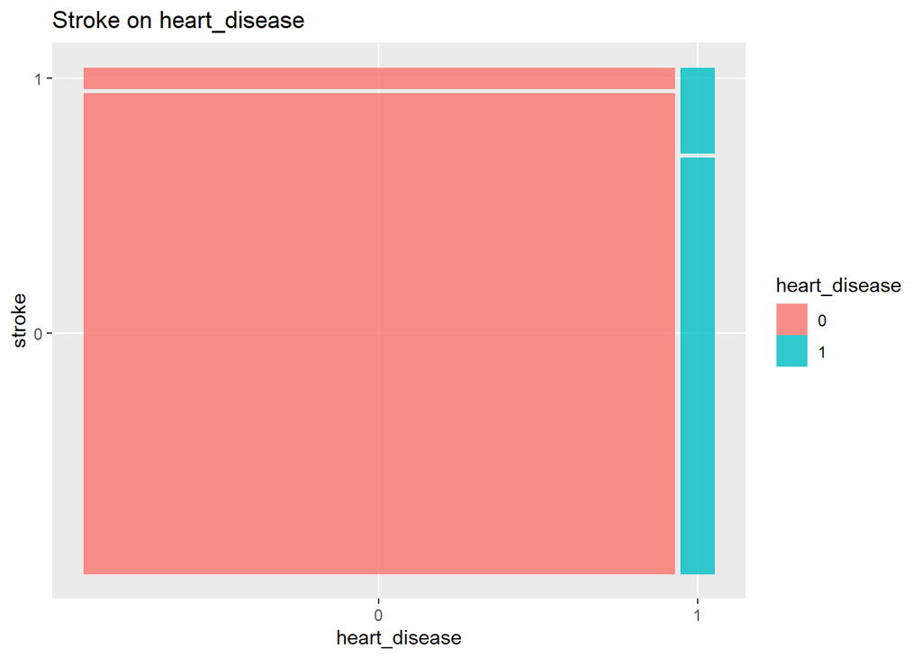

```r
ggplot(data = stroke) +geom_mosaic(aes(x = product(stroke,heart_disease), fill=heart_disease)) + labs(title='Stroke on heart_disease')
```

===> Kết luận: Loại hình công việc self-employed có tỷ lệ đột quỵ cao hơn,người mắc bệnh tim ,có bệnh huyết áp,đã kết hôn có nguy cơ đột quỵ cao hơn người không mắc bệnh và chưa kết hôn, thuốc lá dường như không ảnh hưởng nhiều đến đột quỵ vì tỷ lệ người đã từng hút thuốc cao hơn cả người chưa hút thuốc và đang hút thuốc.

## Để có cái nhìn cụ thể hơn về mối tương quan giữa các biến định lượng đầu vào với nhau và giữa các biến đầu vào với đột quỵ và tỷ lệ tương quan của từng biến, ta dùng biểu đồ nhiệt để hiển thị.

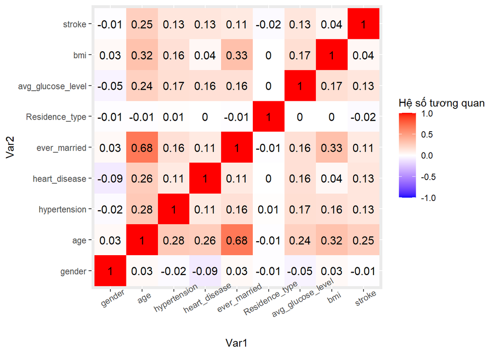

```r
# Chuyển dữ liệu trong stroke1 nông thôn thành 0, thành thị là 1
stroke1$Residence_type[stroke1$Residence_type == "Urban"] <- 0
stroke1$Residence_type[stroke1$Residence_type == "Rural"] <- 1

# Chuyển dữ liệu trong stroke1 đã kết hôn thành 0, đã kết hôn thành 1
stroke1$ever_married[stroke1$ever_married == "Yes"] <- 1
stroke1$ever_married[stroke1$ever_married == "No"] <- 0

# Chuyển dữ liệu trong stroke1 nam: 0, nữ: 1
stroke1$gender[stroke1$gender == "Male"] <- 0
stroke1$gender[stroke1$gender == "Female"] <- 1

suppressWarnings(stroke1$Residence_type <- as.numeric(as.character(stroke1$Residence_type)))
suppressWarnings(stroke1$ever_married <- as.numeric(as.character(stroke1$ever_married)))
suppressWarnings(stroke1$gender <- as.numeric(as.character(stroke1$gender)))

# Tạo bảng đồ tương quan giữa các biến định lượng
stroke.quant = subset(stroke1, select = -c(work_type, smoking_status))
stroke.cor = round(cor(stroke.quant),2)
ggplot(data = reshape2::melt(stroke.cor),aes(x=Var1, y=Var2, fill=value)) + geom_tile() +  scale_fill_gradient2(low = "blue", high = "red", mid = "white", midpoint = 0, limit = c(-1,1), space = "Lab", name="Hệ số tương quan") + geom_text(aes(Var2, Var1, label = value), color = "black", size = 4) + theme(axis.text.x = element_text(angle = 30))
```

===> Kết luận rằng: có thể thấy từ biểu đồ nhiệt, hầu hết các biến không tương quan với nhau, mối tương quan đáng chú ý duy nhất là giữa tuổi tác và tình trạng hôn nhân. Trong số tất cả các đặc điểm, tuổi tác có hệ số tương quan lớn nhất với đột quỵ.Ta chú ý đến sự tương quan của các biến đối với đột quỵ (stroke) thì độ tuổi có hệ số tương quan lớn nhất (0.25) và residence_type có hệ số tương quan nhỏ nhất(-0.02).

## Đối với các biến liên tục, chúng ta cũng có thể sử dụng biểu đồ phân tán để hiển thị mối quan hệ của chúng.

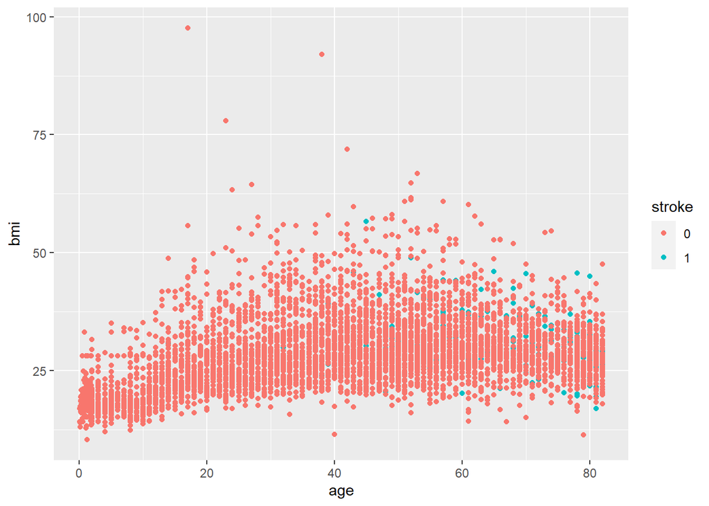

```r
cont.plot <- ggplot(data = stroke, aes(x= age, y = bmi, color = stroke))+geom_point()
cont.plot
```

## Xác định khoảng tuổi có nguy cơ đột quỵ cao nhất

```r
#Trung bình mẫu
strokeAge.mean <-mean(stroke$age[stroke$stroke==1])
strokeAge.mean
```

```
## [1] 67.72819
```

```r
#Độ lệch chuẩn
strokeAge.std <- sd(stroke$age[stroke$stroke==1])
#Độ tin cậy
strokeAge.dtc <-0.95
#Dùng độ tin cậy 95% ta có a/2 =0.475 Tra bảng z=> Za/2(trị số tới hạn)= 1,96
#Sai số chuẩn
strokeAge.ssc <-strokeAge.std / (sqrt(sum(stroke$stroke==1)))
#Phạm vi sai số
pvss <- strokeAge.ssc * 1.96
pvss
```

```
## [1] 1.580872
```

===> Có thể xem độ tuổi trung bình của các bệnh nhân mắc đột quỵ sấp xỉ 68 tuổi và qua xử lý ta có được khoảng tin cậy là [68-1.58;68+1.58]. Vậy người thuộc khoảng trên có nguy cơ đột quỵ cao nhất.

*** Nhận xét: Qua các biểu đồ trực quan hoá, chúng ta sẽ có cái nhìn khách quan về bộ dữ liệu, thông qua đó ta xác định được biến nào có ý nghĩa cao nhất đối với đề tài và biến nào là không cần thiết. không những thế, các biểu đồ còn giúp nhóm đưa ra được kết luận và xác định được hướng đi để trả lời các nghiên cứu tiếp theo, vì dữ liệu rất rộng nếu không trực quan bằng biểu đồ ta không thể tập trung vào các biến có ý nghĩa nhất trong việc giải quyết bài toán.